# Analysis of willow leaf beetle system for github sharing

– Copied at 2026/02/06 from smi_SADIE_beetle.Rmd

– Then copied at 2026/10/27 from smi_SADIE_beetle_v2.Rmd

– Then copied at 2026/10/29 from smi_SADIE_beetle_v3.Rmd; distance between two lines was corrected (from 4m to 2m)

– Universal color

https://okumuralab.org/~okumura/stat/colors.html

### [1] Loading packages and data

– using the leaf beetle data from plant talk project (published as https://www.frontiersin.org/journals/ecology-and-evolution/articles/10.3389/fevo.2022.1031664/full)

```r
R.version
```

```
               _
platform       x86_64-w64-mingw32
arch           x86_64
os             mingw32
crt            ucrt
system         x86_64, mingw32
status
major          4
minor          5.3
year           2026
month          03
day            11
svn rev        89597
language       R
version.string R version 4.5.3 (2026-03-11 ucrt)
nickname       Reassured Reassurer
```

```r
Sys.setlocale("LC_ALL", "English")
```

```
[1] "LC_COLLATE=English_United States.1252;LC_CTYPE=English_United States.1252;LC_MONETARY=English_United States.1252;LC_NUMERIC=C;LC_TIME=English_United States.1252"
```

```r
library(vegan)
library(epiphy)
library(MASS)
library(MuMIn)
library(ggplot2)
library(animation)
library(gganimate)
library(gifski)
library(jpeg)
library(png)
library(car)
library(rgl)
library(nlme) # for using gls()
library(spdep) # Moran's I
source("C:/Users/biomiki/Dropbox/r_local/plot_mod_epiphy.R")
```

```r
##########data loading###########################3
first_day_data <- read.csv("./first-day.csv", header = T)
day2_7_data <- read.csv("./day2-7.csv", header = T)
day10_60_data <- read.csv("./d10-d60.csv", header = T)
```

–Data check, only using the adult numbers

```r
print(first_day_data)
```

| time | hour | days | period | time.1 | id | treatment | A | E | lb | L.P | P | P.A |
| --- | --- | --- | --- | --- | --- | --- | --- | --- | --- | --- | --- | --- |
| 6.10-07:00 | 1 | 1 | P1 | 1 | non01 | non | 0 | 0 | 0 | 0 | 0 | 0 |
| 6.10-07:00 | 1 | 1 | P1 | 1 | non02 | non | 0 | 0 | 0 | 0 | 0 | 0 |
| 6.10-07:00 | 1 | 1 | P1 | 1 | non03 | non | 0 | 0 | 0 | 0 | 0 | 0 |
| 6.10-07:00 | 1 | 1 | P1 | 1 | non04 | non | 0 | 0 | 0 | 0 | 0 | 0 |
| 6.10-07:00 | 1 | 1 | P1 | 1 | non05 | non | 0 | 0 | 0 | 0 | 0 | 0 |
| 6.10-07:00 | 1 | 1 | P1 | 1 | non06 | non | 0 | 0 | 0 | 0 | 0 | 0 |
| 6.10-07:00 | 1 | 1 | P1 | 1 | non07 | non | 0 | 0 | 0 | 0 | 0 | 0 |
| 6.10-07:00 | 1 | 1 | P1 | 1 | non08 | non | 0 | 0 | 0 | 0 | 0 | 0 |
| 6.10-07:00 | 1 | 1 | P1 | 1 | non09 | non | 0 | 0 | 0 | 0 | 0 | 0 |
| 6.10-07:00 | 1 | 1 | P1 | 1 | non10 | non | 0 | 0 | 0 | 0 | 0 | 0 |

[output cut: 470 more lines]

```r
print(day2_7_data)
```

| time | days | day | sample | treatment | A | total.Ruri |
| --- | --- | --- | --- | --- | --- | --- |
| 6.11-09:00 | 2 | 2.0 | non01 | non | 0 | 0 |
| 6.11-09:00 | 2 | 2.0 | non02 | non | 0 | 0 |
| 6.11-09:00 | 2 | 2.0 | non03 | non | 5 | 5 |
| 6.11-09:00 | 2 | 2.0 | non04 | non | 0 | 0 |
| 6.11-09:00 | 2 | 2.0 | non05 | non | 1 | 1 |
| 6.11-09:00 | 2 | 2.0 | non06 | non | 0 | 0 |
| 6.11-09:00 | 2 | 2.0 | non07 | non | 0 | 0 |
| 6.11-09:00 | 2 | 2.0 | non08 | non | 2 | 2 |
| 6.11-09:00 | 2 | 2.0 | non09 | non | 0 | 0 |
| 6.11-09:00 | 2 | 2.0 | non10 | non | 0 | 0 |

[output cut: 990 more lines]

```r
print(day10_60_data)
```

| time | days | period | time.1 | id | treatment | A | E | lb | L.P | P | P.A | total_L.P | total_A | total_Ruri |
| --- | --- | --- | --- | --- | --- | --- | --- | --- | --- | --- | --- | --- | --- | --- |
| 6.19-09:00 | 10 | P2 | 25 | non01 | non | 4 | 13 | 0 | 0 | 0 | 0 | 0 | 4 | 17 |
| 6.19-09:00 | 10 | P2 | 25 | non02 | non | 8 | 0 | 0 | 0 | 0 | 0 | 0 | 8 | 8 |
| 6.19-09:00 | 10 | P2 | 25 | non03 | non | 5 | 18 | 8 | 0 | 0 | 0 | 8 | 5 | 31 |
| 6.19-09:00 | 10 | P2 | 25 | non04 | non | 0 | 0 | 0 | 0 | 0 | 0 | 0 | 0 | 0 |
| 6.19-09:00 | 10 | P2 | 25 | non05 | non | 6 | 53 | 0 | 0 | 0 | 0 | 0 | 6 | 59 |
| 6.19-09:00 | 10 | P2 | 25 | non06 | non | 0 | 0 | 0 | 0 | 0 | 0 | 0 | 0 | 0 |
| 6.19-09:00 | 10 | P2 | 25 | non07 | non | 1 | 0 | 0 | 0 | 0 | 0 | 0 | 1 | 1 |
| 6.19-09:00 | 10 | P2 | 25 | non08 | non | 0 | 5 | 31 | 0 | 0 | 0 | 31 | 0 | 36 |
| 6.19-09:00 | 10 | P2 | 25 | non09 | non | 3 | 0 | 0 | 0 | 0 | 0 | 0 | 3 | 3 |
| 6.19-09:00 | 10 | P2 | 25 | non10 | non | 3 | 8 | 0 | 0 | 0 | 0 | 0 | 3 | 11 |

[output cut: 374 more lines]

– Time assignment

```r
time_points <- numeric(30)
unique(first_day_data$time)
```

```
 [1] "6.10-07:00" "6.10-08:00" "6.10-09:00" "6.10-10:00" "6.10-11:00"
 [6] "6.10-12:00" "6.10-14:00" "6.10-16:00" "6.10-18:00" "6.11-07:00"
```

```r
unique(day2_7_data$time)
```

```
 [1] "6.11-09:00" "6.11-16:00" "6.12-09:00" "6.12-16:00" "6.13-09:00"
 [6] "6.13-16:00" "6.14-09:00" "6.14-16:00" "6.15-09:00" "6.15-16:00"
[11] "6.16-09:00" "6.16-16:00" ""
```

```r
unique(day10_60_data$time)
```

```
[1] "6.19-09:00"  "6.19-16:00"  "7.10-09:00-" "7.10-16:00-" "7.11-9:00-"
[6] "8.07-09:00-" "8.07-16:00-" "8.08-9:00-"
```

```r
time_points[1:10] <- c(1:6, 8, 10, 12, 25)
# time_points[11] <- time_points[10] + 2
# time_points[12] <- time_points[11] + 7
# time_points[13] <- time_points[11] + 24
# time_points[14] <- time_points[13] + 7


for(k in 1:10) {
  time_points[11:22] <- c(time_points[10] + 2, time_points[11] + 7,
                        time_points[11] + 24, time_points[13] + 7,
                        time_points[13] + 24, time_points[15] + 7,
                        time_points[15] + 24, time_points[17] + 7,
                        time_points[17] + 24, time_points[19] + 7,
                        time_points[19] + 24, time_points[21] + 7
                        )
  time_points[23:30] <- c(time_points[11] + 24*8, time_points[23] + 7,
                        time_points[23] + 24*21, time_points[25] + 7,
                        time_points[25] + 24,
                        time_points[27] + 24*27, time_points[28] + 7,
                        time_points[28] + 24
                        )
}
time_points
```

```
 [1]    1    2    3    4    5    6    8   10   12   25   27   34   51   58
[15]   75   82   99  106  123  130  147  154  219  226  723  730  747 1395
[29] 1402 1419
```

### [2] Basic analysis and visualization

#### [2.1] Functions to calculate the following metrics

– modified from those in the chytrid analysis

- infestation_ratio, the ratio of the trees with herbivory)
- average adult number (ave_basic), the total number of adults divided by the whole tree number
- average herbivory impact (average_impact), the total number of adults divided by the number of trees with herbivory
- deviation from Poisson distribution
- standardized morisita index

```r
#########new function at 2022/04/06: preparation for kibanA2023##############
spatial_distr_simple <- function(data0, title = "green", x_max = 10, LOG = F, drawing = FALSE) {

  # basic statistics
  ave_basic <- ave(data0)
  var_basic <- var(data0)
  cv_basic <- sqrt(var_basic)/ave_basic

  # Convert raw data into frequency distribution
  cut_test <- cut(data0, breaks = seq(-1, max(data0), by = 1))
  freq_dist <- as.data.frame(table(cut_test))

  infestation_ratio <- 1 - freq_dist$Freq[1] / sum(freq_dist$Freq)

  # delete long tail with NA
  data <- subset(freq_dist$Freq, complete.cases(freq_dist$Freq))
  # infestations
  infestations = 0:(length(data) - 1)
  # observed
  observed = c(data)
  total = sum(observed)

  # See the estimation of lamda http://www.singularpoint.org/blog/math/stat/cramer-rao-2/
  # https://www.statlect.com/fundamentals-of-statistics/Poisson-distribution-maximum-likelihood

  lambda = sum(infestations * observed) / total

  average_impact = sum(infestations * observed) / (total - observed[1])

  expected = total * ((lambda ^ infestations) * exp(-lambda)) / factorial(infestations)
  chi.squared = (observed - expected) ^ 2 / expected
  chi.squared.statistic = sum(chi.squared)

  #P Value for the Poisson distribution
  #https://web.stanford.edu/class/psych252/cheatsheets/chisquare.html
  P_chisq_Poission <- pchisq(chi.squared.statistic, length(observed) - 2, lower.tail = F)

  xmax <- x_max

  if(drawing == TRUE) {
    if(LOG == T) {
      plot(infestations, log10(observed), xlim = c(0,xmax), ylim = c(-0,3), cex = 3, pch = 16, cex.axis = 2, main = title)
      lines(infestations, log10(expected), col = 1,cex = 2, lwd = 3, lty = 2) #pure Poisson
    }
    else {
      plot(infestations, observed, xlim = c(0, xmax), cex = 3, ylim = c(0, max(observed + 10)), main = title)
      lines(infestations, expected, col = 1, cex = 2, lwd = 3,lty = 2) #pure Poisson
    }
  }

  morisita <- dispindmorisita(data0, unique.rm = FALSE, crit = 0.05)

  #imst is the standardized Morisita index: (-0.5:0.5) are confidence interval for random distribution
  cat("The ratio of infestations among trees is:", infestation_ratio, "\n")
  cat("The averaged number of infestations per tree is:", lambda, "\n")
  cat("The averaged number of infestations per infested tree is:", average_impact, "\n")
  cat("The probability with which Poisson distribution generates more extreme deviation:", P_chisq_Poission, "\n")
  cat("The CV is :", cv_basic[1], "\n")
  cat("The standardized morisita index value is :", morisita$imst, "\n")

  # return dataframe
  results_df <- data.frame(infestation_ratio, av_pop = lambda, av_impact = average_impact, smi = morisita$imst)
  return(results_df)

}
```

– specific growth rate

```r
specific_growth <- function(value_vec, time_vec, tau = 1) {
  vec_length <- length(value_vec)
  growth <- numeric(vec_length)

  for(j in 1:vec_length) {
    if(j + tau - 1 < 1 || j + tau > vec_length) growth[j] <- NA
    else {
      growth[j] <- log(value_vec[j + tau] / value_vec[j + tau - 1]) / (time_vec[j + tau] - time_vec[j + tau - 1])
      if(value_vec[j + tau] == 0 & value_vec[j + tau - 1] == 0) growth[j] <- 0 #exception
    }
    if(is.infinite(growth[j])) growth[j] <- NA
  }
  # Noting that the value is not calculated at the final time point
  return(growth)
}
```

#### [2.2] Data pretreatment and summary

– extract adult number sequence at each monitoring point and assigned into the matrix, noting that the time interval is heterogeneous.

```r
####d ecomposing the data into temporal snapshot
class(first_day_data$hour)
```

```
[1] "integer"
```

```r
hour_A <- matrix(nrow = 30, ncol = 48)
for(i in 1:6) hour_A[i,] <- subset(first_day_data, first_day_data$hour == i)$A
hour_A[7,] <- subset(first_day_data, first_day_data$hour == 8)$A
hour_A[8,] <- subset(first_day_data, first_day_data$hour == 10)$A
hour_A[9,] <- subset(first_day_data, first_day_data$hour == 12)$A
hour_A[10,] <- subset(first_day_data, first_day_data$hour == 24)$A
hour_A[10,]
```

```
 [1] 0 0 4 0 1 0 0 1 0 1 0 0 0 0 0 1 0 0 0 0 0 0 0 0 0 0 0 0 1 0 0 0 0 0 0 0 0
[38] 0 0 1 0 0 0 0 0 0 0 0
```

```r
hour_A[11,] <- subset(day2_7_data, day2_7_data$day == 2.0)$A
hour_A[12,] <- subset(day2_7_data, day2_7_data$day == 2.5)$A
hour_A[13,] <- subset(day2_7_data, day2_7_data$day == 3.0)$A
hour_A[14,] <- subset(day2_7_data, day2_7_data$day == 3.5)$A
hour_A[15,] <- subset(day2_7_data, day2_7_data$day == 4.0)$A
hour_A[16,] <- subset(day2_7_data, day2_7_data$day == 4.5)$A
hour_A[17,] <- subset(day2_7_data, day2_7_data$day == 5.0)$A
hour_A[18,] <- subset(day2_7_data, day2_7_data$day == 5.5)$A
hour_A[19,] <- subset(day2_7_data, day2_7_data$day == 6.0)$A
hour_A[20,] <- subset(day2_7_data, day2_7_data$day == 6.5)$A
hour_A[21,] <- subset(day2_7_data, day2_7_data$day == 7.0)$A
hour_A[22,] <- subset(day2_7_data, day2_7_data$day == 7.5)$A
hour_A[23,] <- subset(day10_60_data, day10_60_data$time.1 == 25)$A
hour_A[24,] <- subset(day10_60_data, day10_60_data$time.1 == 26)$A
hour_A[25,] <- subset(day10_60_data, day10_60_data$time.1 == 28)$A
hour_A[26,] <- subset(day10_60_data, day10_60_data$time.1 == 29)$A
hour_A[27,] <- subset(day10_60_data, day10_60_data$time.1 == 30)$A
hour_A[28,] <- subset(day10_60_data, day10_60_data$time.1 == 32)$A
hour_A[29,] <- subset(day10_60_data, day10_60_data$time.1 == 33)$A
hour_A[30,] <- subset(day10_60_data, day10_60_data$time.1 == 34)$A
#converting matrix to dataframe
as.data.frame(hour_A)
```

| V1 | V2 | V3 | V4 | V5 | V6 | V7 | V8 | V9 | V10 | V11 | V12 | V13 | V14 | V15 | V16 | V17 | V18 | V19 | V20 | V21 | V22 | V23 | V24 | V25 | V26 | V27 | V28 | V29 | V30 | … |
| --- | --- | --- | --- | --- | --- | --- | --- | --- | --- | --- | --- | --- | --- | --- | --- | --- | --- | --- | --- | --- | --- | --- | --- | --- | --- | --- | --- | --- | --- | --- |
| 0 | 0 | 0 | 0 | 0 | 0 | 0 | 0 | 0 | 0 | 0 | 0 | 0 | 0 | 0 | 0 | 0 | 0 | 0 | 0 | 0 | 0 | 0 | 0 | 0 | 0 | 0 | 0 | 0 | 0 | … |
| 0 | 0 | 0 | 0 | 0 | 0 | 0 | 0 | 0 | 0 | 0 | 0 | 0 | 0 | 0 | 0 | 0 | 0 | 0 | 0 | 0 | 0 | 0 | 0 | 0 | 0 | 0 | 0 | 0 | 0 | … |
| 0 | 0 | 0 | 0 | 0 | 0 | 0 | 0 | 0 | 0 | 0 | 0 | 0 | 0 | 0 | 0 | 0 | 0 | 0 | 0 | 0 | 0 | 0 | 0 | 0 | 0 | 0 | 0 | 0 | 0 | … |
| 0 | 0 | 0 | 0 | 0 | 0 | 0 | 0 | 0 | 0 | 1 | 0 | 0 | 0 | 0 | 0 | 0 | 0 | 0 | 0 | 0 | 0 | 0 | 0 | 0 | 0 | 0 | 0 | 0 | 0 | … |
| 0 | 0 | 0 | 0 | 0 | 0 | 0 | 0 | 0 | 0 | 0 | 0 | 0 | 0 | 0 | 0 | 0 | 0 | 0 | 0 | 0 | 0 | 0 | 0 | 0 | 0 | 0 | 0 | 0 | 0 | … |
| 0 | 0 | 0 | 0 | 1 | 0 | 0 | 0 | 0 | 1 | 0 | 0 | 0 | 0 | 0 | 0 | 0 | 0 | 0 | 0 | 0 | 0 | 0 | 0 | 0 | 0 | 0 | 0 | 0 | 0 | … |
| 0 | 0 | 3 | 0 | 1 | 0 | 0 | 0 | 0 | 1 | 0 | 0 | 0 | 0 | 0 | 0 | 0 | 0 | 0 | 0 | 0 | 0 | 0 | 0 | 0 | 0 | 0 | 0 | 1 | 0 | … |
| 0 | 0 | 4 | 0 | 1 | 0 | 0 | 1 | 0 | 1 | 0 | 0 | 0 | 0 | 0 | 0 | 0 | 0 | 0 | 0 | 0 | 0 | 0 | 0 | 0 | 0 | 0 | 0 | 1 | 0 | … |
| 0 | 0 | 4 | 0 | 1 | 0 | 0 | 1 | 0 | 1 | 0 | 0 | 0 | 0 | 0 | 1 | 0 | 0 | 0 | 0 | 0 | 0 | 0 | 0 | 0 | 0 | 0 | 0 | 1 | 0 | … |
| 0 | 0 | 4 | 0 | 1 | 0 | 0 | 1 | 0 | 1 | 0 | 0 | 0 | 0 | 0 | 1 | 0 | 0 | 0 | 0 | 0 | 0 | 0 | 0 | 0 | 0 | 0 | 0 | 1 | 0 | … |

[output cut: 20 more lines]

#### [2.3] Addition of spatial info (necessary for SADIE analysis), correctd at 2026/10/29

```r
salix_position <- read.csv("./salix_position2.csv", header = T)
salix_position
```

| ID | X | Y |
| --- | --- | --- |
| non01 | 0 | -4 |
| non02 | 0 | -5 |
| non03 | 0 | -10 |
| non04 | 0 | -12 |
| non05 | 0 | -19 |
| non06 | 0 | -20 |
| non07 | 0 | -28 |
| non08 | 0 | -30 |
| non09 | 2 | -3 |
| non10 | 2 | -5 |

[output cut: 38 more lines]

#### [2.4] Calculating morisita index and other characteristics

```
The ratio of infestations among trees is: 0.1041667
The averaged number of infestations per tree is: 0.1666667
The averaged number of infestations per infested tree is: 1.6
The probability with which Poisson distribution generates more extreme deviation: 1.386304e-165
The CV is : 3.781253
The standardized morisita index value is : 0.571678
```

| infestation_ratio | av_pop | av_impact | smi |
| --- | --- | --- | --- |
| 0.1041667 | 0.1666667 | 1.6 | 0.571678 |

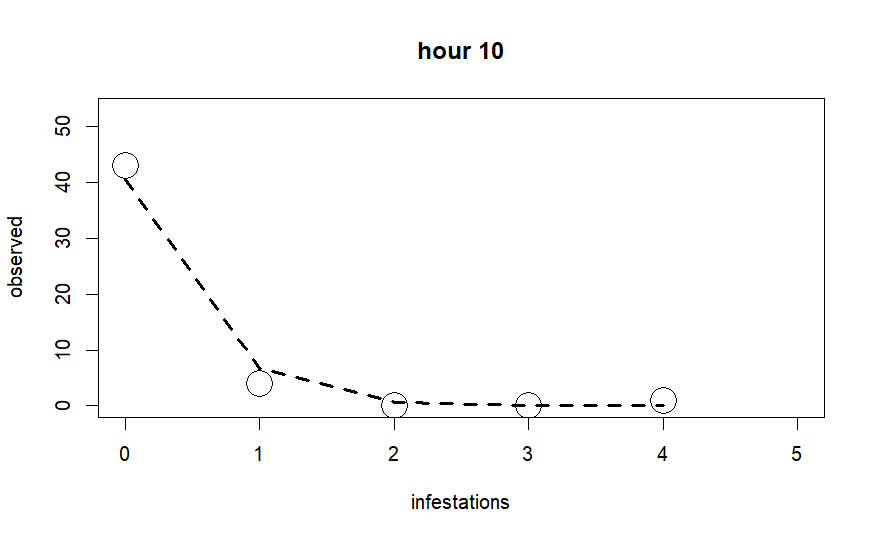

```r
spatial_distr_simple(hour_A[8,], x_max = max(hour_A[8,]) + 1, title = paste("hour", time_points[8]), drawing = TRUE)
```

```r
#####Poisson and morisita test
beetle_summary <- NULL

for(j in 1:30) {
  temp_df <- spatial_distr_simple(hour_A[j, ])
  temp_df2 <- data.frame(time = time_points[j], temp_df)
  beetle_summary <- rbind.data.frame(beetle_summary, temp_df2)
}
```

```
The ratio of infestations among trees is: 0
The averaged number of infestations per tree is: 0
The averaged number of infestations per infested tree is: NaN
The probability with which Poisson distribution generates more extreme deviation: NaN
The CV is : NaN
The standardized morisita index value is : NaN
```

```
The ratio of infestations among trees is: 0
The averaged number of infestations per tree is: 0
The averaged number of infestations per infested tree is: NaN
The probability with which Poisson distribution generates more extreme deviation: NaN
The CV is : NaN
The standardized morisita index value is : NaN
```

```
The ratio of infestations among trees is: 0
The averaged number of infestations per tree is: 0
The averaged number of infestations per infested tree is: NaN
The probability with which Poisson distribution generates more extreme deviation: NaN
The CV is : NaN
The standardized morisita index value is : NaN
The ratio of infestations among trees is: 0.02083333
The averaged number of infestations per tree is: 0.02083333
The averaged number of infestations per infested tree is: 1
The probability with which Poisson distribution generates more extreme deviation: 0
The CV is : 6.928203
The standardized morisita index value is : NaN
```

```
The ratio of infestations among trees is: 0
The averaged number of infestations per tree is: 0
The averaged number of infestations per infested tree is: NaN
The probability with which Poisson distribution generates more extreme deviation: NaN
The CV is : NaN
The standardized morisita index value is : NaN
The ratio of infestations among trees is: 0.04166667
The averaged number of infestations per tree is: 0.04166667
The averaged number of infestations per infested tree is: 1
The probability with which Poisson distribution generates more extreme deviation: 0
The CV is : 4.846582
The standardized morisita index value is : -0.02933617
The ratio of infestations among trees is: 0.1041667
The averaged number of infestations per tree is: 0.1458333
The averaged number of infestations per infested tree is: 1.4
The probability with which Poisson distribution generates more extreme deviation: 1.109739e-10
The CV is : 3.461845
The standardized morisita index value is : 0.5274183
The ratio of infestations among trees is: 0.1041667
The averaged number of infestations per tree is: 0.1666667
The averaged number of infestations per infested tree is: 1.6
The probability with which Poisson distribution generates more extreme deviation: 1.386304e-165
The CV is : 3.781253
The standardized morisita index value is : 0.571678
The ratio of infestations among trees is: 0.125
The averaged number of infestations per tree is: 0.1875
The averaged number of infestations per infested tree is: 1.5
The probability with which Poisson distribution generates more extreme deviation: 2.262791e-105
The CV is : 3.418763
The standardized morisita index value is : 0.5495234
The ratio of infestations among trees is: 0.1458333
The averaged number of infestations per tree is: 0.2083333
The averaged number of infestations per infested tree is: 1.428571
The probability with which Poisson distribution generates more extreme deviation: 1.858945e-70
The CV is : 3.124645
The standardized morisita index value is : 0.534536
The ratio of infestations among trees is: 0.125
The averaged number of infestations per tree is: 0.2291667
The averaged number of infestations per infested tree is: 1.833333
The probability with which Poisson distribution generates more extreme deviation: 0
```

[output cut: 101 more lines]

```
The probability with which Poisson distribution generates more extreme deviation: 0
The CV is : 3.351722
The standardized morisita index value is : -0.08800852
The ratio of infestations among trees is: 0.04166667
The averaged number of infestations per tree is: 0.04166667
The averaged number of infestations per infested tree is: 1
The probability with which Poisson distribution generates more extreme deviation: 0
The CV is : 4.846582
The standardized morisita index value is : -0.02933617
The ratio of infestations among trees is: 0.0625
The averaged number of infestations per tree is: 0.0625
The averaged number of infestations per infested tree is: 1
The probability with which Poisson distribution generates more extreme deviation: 0
The CV is : 3.913968
The standardized morisita index value is : -0.05867235
```

```r
print(beetle_summary)
```

| time | infestation_ratio | av_pop | av_impact | smi |
| --- | --- | --- | --- | --- |
| 1 | 0.00000000 | 0.00000000 | NaN | NaN |
| 2 | 0.00000000 | 0.00000000 | NaN | NaN |
| 3 | 0.00000000 | 0.00000000 | NaN | NaN |
| 4 | 0.02083333 | 0.02083333 | 1.000000 | NaN |
| 5 | 0.00000000 | 0.00000000 | NaN | NaN |
| 6 | 0.04166667 | 0.04166667 | 1.000000 | -0.02933617 |
| 8 | 0.10416667 | 0.14583333 | 1.400000 | 0.52741834 |
| 10 | 0.10416667 | 0.16666667 | 1.600000 | 0.57167799 |
| 12 | 0.12500000 | 0.18750000 | 1.500000 | 0.54952336 |
| 25 | 0.14583333 | 0.20833333 | 1.428571 | 0.53453603 |

[output cut: 20 more lines]

– Calculating growth rates and adding them into the summary dataframe - With tau = 1 (the growth to the next step)

```r
beetle_summary$pop_growth_1 <- specific_growth(beetle_summary$av_pop, beetle_summary$time)
beetle_summary$prev_growth_1 <- specific_growth(beetle_summary$infestation_ratio, beetle_summary$time)

print(beetle_summary)
```

| time | infestation_ratio | av_pop | av_impact | smi | pop_growth_1 | prev_growth_1 |
| --- | --- | --- | --- | --- | --- | --- |
| 1 | 0.00000000 | 0.00000000 | NaN | NaN | 0.000000000 | 0.000000000 |
| 2 | 0.00000000 | 0.00000000 | NaN | NaN | 0.000000000 | 0.000000000 |
| 3 | 0.00000000 | 0.00000000 | NaN | NaN | NA | NA |
| 4 | 0.02083333 | 0.02083333 | 1.000000 | NaN | NA | NA |
| 5 | 0.00000000 | 0.00000000 | NaN | NaN | NA | NA |
| 6 | 0.04166667 | 0.04166667 | 1.000000 | -0.02933617 | 0.626381484 | 0.458145366 |
| 8 | 0.10416667 | 0.14583333 | 1.400000 | 0.52741834 | 0.066765696 | 0.000000000 |
| 10 | 0.10416667 | 0.16666667 | 1.600000 | 0.57167799 | 0.058891518 | 0.091160778 |
| 12 | 0.12500000 | 0.18750000 | 1.500000 | 0.54952336 | 0.008104655 | 0.011857745 |
| 25 | 0.14583333 | 0.20833333 | 1.428571 | 0.53453603 | 0.047655090 | -0.077075340 |

[output cut: 20 more lines]

#### [2.5] Basic visualization

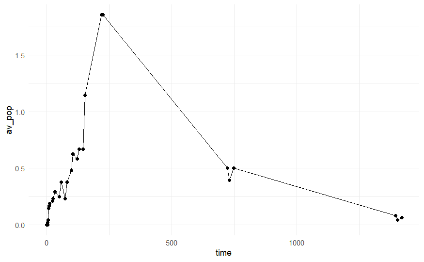

```r
ggplot(beetle_summary, aes(x = time, y = av_pop)) +
  geom_line() +
  geom_point() +
  #scale_y_log10() +
  theme_minimal()
```

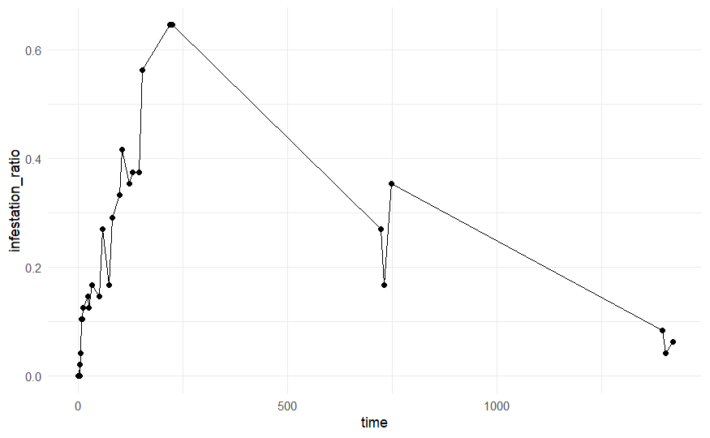

```r
ggplot(beetle_summary, aes(x = time, y = infestation_ratio)) +
  geom_line() +
  geom_point() +
  #scale_y_log10() +
  theme_minimal()
```

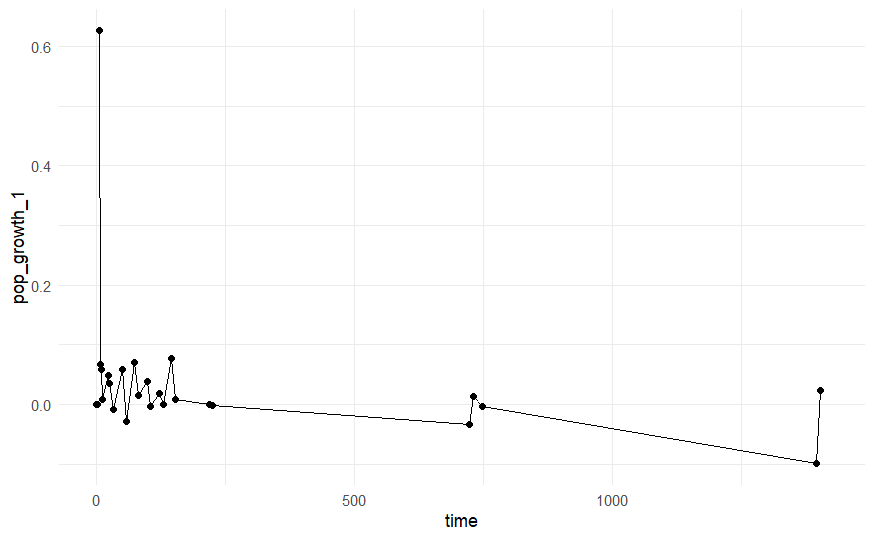

```r
ggplot(beetle_summary, aes(x = time, y = pop_growth_1)) +
  geom_line() +
  geom_point() +
  #scale_y_log10() +
  theme_minimal()
```

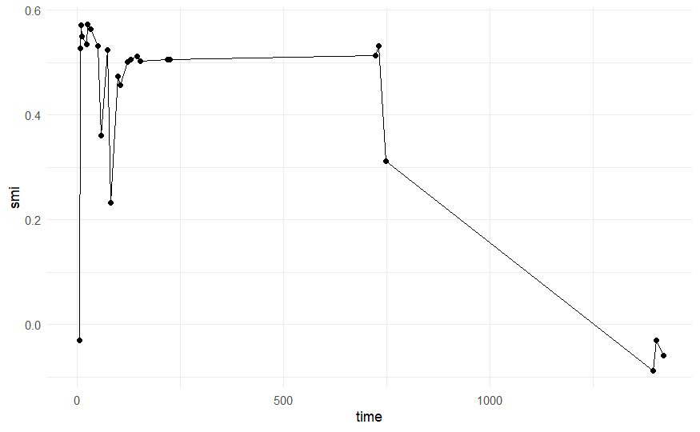

```r
ggplot(beetle_summary, aes(x = time, y = smi)) +
  geom_line() +
  geom_point() +
  #scale_y_log10() +
  theme_minimal()
```

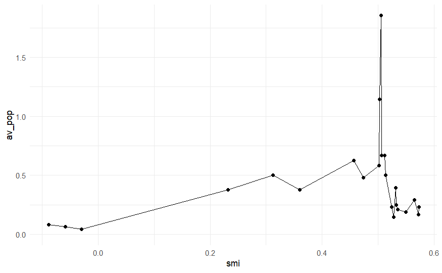

```r
ggplot(beetle_summary, aes(x = smi, y = av_pop)) +
  geom_line() +
  geom_point() +
  #scale_y_log10() +
  theme_minimal()
```

### [3] SADIE Calculation

```r
adult_time_space <- data.frame(time = rep(1, 48), salix_position, adult = hour_A[1, ])
for(i in 2:30){
  adult_time_space <- rbind.data.frame(adult_time_space, data.frame(time = rep(i, 48), salix_position, adult = hour_A[i, ]))
}
adult_time_space
```

| time | ID | X | Y | adult |
| --- | --- | --- | --- | --- |
| 1 | non01 | 0 | -4 | 0 |
| 1 | non02 | 0 | -5 | 0 |
| 1 | non03 | 0 | -10 | 0 |
| 1 | non04 | 0 | -12 | 0 |
| 1 | non05 | 0 | -19 | 0 |
| 1 | non06 | 0 | -20 | 0 |
| 1 | non07 | 0 | -28 | 0 |
| 1 | non08 | 0 | -30 | 0 |
| 1 | non09 | 2 | -3 | 0 |
| 1 | non10 | 2 | -5 | 0 |

[output cut: 990 more lines]

- Codes for animation

```r
# setting the max and min for color gradient
adult_min <- 0
adult_max <- 10

base_plot <- ggplot(adult_time_space, aes(x = X, y = Y, fill = adult)) +
  geom_tile() +
  scale_fill_gradient(low = "white", high = "blue", limits = c(adult_min, adult_max)) +
  labs(title = "Leaf Beetle adult distributions",
       x = "Axis from North to South",
       y = "Axis from West to East",
       fill = "Adult") + coord_fixed(ratio = 3.0) +
  theme_minimal()

animation <- base_plot +
  transition_time(time) +
  labs(title = "LB adult: Time {frame_time}")

# presenting animation (no interpolation)
animate(animation, nframes = 30, fps = 1, renderer = gifski_renderer("LB_adult.gif"))
```

[output not shown]

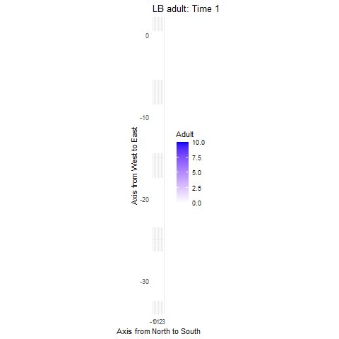

Spatial Distribution Animation all

#### [3.2] Calculating SADIE

– data preparation and examples

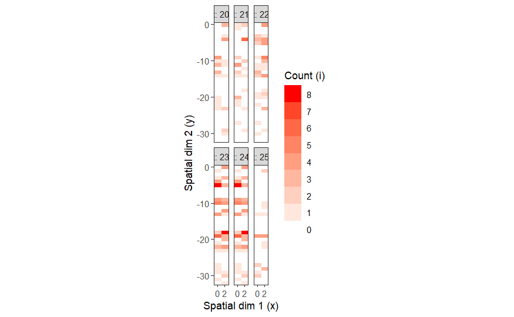

```r
adult_time_space_sub <- subset(adult_time_space, (time >= 20 & time <= 25))
count_data_sub <- epiphy::count(adult_time_space_sub, mapping(x = X, y = Y, t = time, i = adult))
plot(count_data_sub, tile = TRUE, size = 4)
```

##### [3.2.1] Calculating SADIE for all time steps (for loop)

```r
set.seed(1234)
res_sadie <- list()
for(i in 1:length(unique(adult_time_space$time))) {
  cat("+")
  data_sub <- subset(adult_time_space, time == i)
  count_data_sub <- epiphy::count(data_sub, mapping(x = X, y = Y, t = time, i = adult))
  if(sum(count_data_sub$data$adult) < 1) next
  capture.output(res_sadie[[i]] <- sadie(count_data_sub, index = "all", threads = 2))
}
```

```
++++++++++++++++++++++++++++++
```

##### [3.2.2] Visualization of SADIE results

```r
plot(res_sadie[[6]], main = "test")
saveGIF(
  {
    for(i in 1:30) {
      if(is.null(res_sadie[[i]])) {
        frame()
        next
      }
      plot(res_sadie[[i]], index = "Perry", main = paste("time", i))
    }
  }, interval = 1.0, movie.name = "Perry_LB.gif"
)
```

```
[1] TRUE
```

```
[1] TRUE
```

[figure not shown]

```r
saveGIF(
  {
    for(i in 1:30) {
      if(is.null(res_sadie[[i]])) {
        frame()
        next
      }
      plot(res_sadie[[i]], index = "Li-Madden-Xu", main = paste("time", i))
    }
  }, interval = 1.0, movie.name = "LMX_LB.gif"
)
```

### [4] Spatial autocorrelation

#### [4.1] Trial of Moran’s I calculation

– Define the neighbors by the distance <= 3*sqrt(2) and its visualization

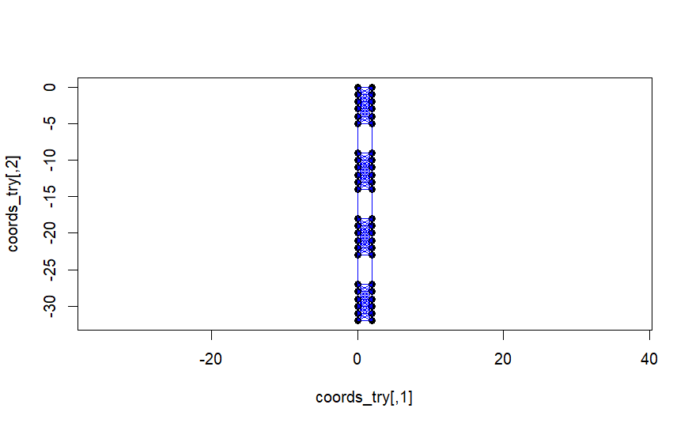

```r
max_dist <- 3.0*sqrt(2)
try_time10 <- subset(adult_time_space, time == 10)
coords_try <- cbind(try_time10$X, try_time10$Y) #extract coordinates
nb_try <- dnearneigh(coords_try, 0, max_dist) #define the neighborhood
plot(coords_try, asp = 1, pch = 19)
plot(nb_try, coords_try, add = TRUE, col = "blue")
```

```r
lw_try <- nb2listw(nb_try, style = "W") #weighted-spatial matrix
```

– Global (and Local) Moran’s I

```r
moran.test(try_time10$adult, lw_try)
```

```
    Moran I test under randomisation

data:  try_time10$adult
weights: lw_try

Moran I statistic standard deviate = -1.1289, p-value = 0.8705
alternative hypothesis: greater
sample estimates:
Moran I statistic       Expectation          Variance
     -0.066447952      -0.021276596       0.001601111
```

```r
#localmoran(try_time10$adult, lw_try)
moran.test(try_time10$adult, lw_try)$statistic
```

```
Moran I statistic standard deviate
                         -1.128892
```

#### [4.2] Moran’s I calculation for all time steps (for loop)

```r
res_moran <- list()
max_dist <- 3.0*sqrt(2)
for(i in 1:length(unique(adult_time_space$time))) {
  cat("+")
  data_sub <- subset(adult_time_space, time == i)
  coords_sub <- cbind(data_sub$X, data_sub$Y) #extract coordinates
  nb_sub <- dnearneigh(coords_sub, 0, max_dist)
  lw_sub <- nb2listw(nb_sub, style = "W")
  if(sum(data_sub$adult) < 1) {
    res_moran[[i]] <- NA
    next
  }
  res_moran[[i]] <- moran.test(data_sub$adult, lw_sub)$statistic
}
```

```
++++++++++++++++++++++++++++++
```

```r
#save.image("willow_beetle20260221.RData")
#save.image("willow_beetle20261029.RData")
```

### [5] Time series analysis

```r
#load("willow_beetle20260221.RData")
#load("willow_beetle20260528.RData")
load("willow_beetle20261029.RData")
```

- prepare several lists

```r
candidate_formulas <- list()
fits_gls <- list()
results_table <- list()
final_fit <- list()
best_model_name <- list()
best_formula <- list()
```

#### [5.1] Data summarization

Adding SADIE results into the dataframe (beetle_summary)

```r
beetle_summary$Perry <- NA
beetle_summary$LMX <- NA
beetle_summary$Ia <- NA
for(i in 1:30) {
  if(is.null(res_sadie[[i]])) next
  beetle_summary$Perry[i] <- res_sadie[[i]]$summary_idx[1, 1]
  beetle_summary$LMX[i] <- res_sadie[[i]]$summary_idx[2, 1]
  beetle_summary$Ia[i] <- res_sadie[[i]]$Ia
}
beetle_summary$moran <- unlist(res_moran)
print(beetle_summary)
```

| time | infestation_ratio | av_pop | av_impact | smi | pop_growth_1 | prev_growth_1 | Perry | LMX | Ia | moran |
| --- | --- | --- | --- | --- | --- | --- | --- | --- | --- | --- |
| 1 | 0.00000000 | 0.00000000 | NaN | NaN | 0.000000000 | 0.000000000 | NA | NA | NA | NA |
| 2 | 0.00000000 | 0.00000000 | NaN | NaN | 0.000000000 | 0.000000000 | NA | NA | NA | NA |
| 3 | 0.00000000 | 0.00000000 | NaN | NaN | NA | NA | NA | NA | NA | NA |
| 4 | 0.02083333 | 0.02083333 | 1.000000 | NaN | NA | NA | 0.8103045 | 0.7746367 | 0.8067476 | -1.03435848 |
| 5 | 0.00000000 | 0.00000000 | NaN | NaN | NA | NA | NA | NA | NA | NA |
| 6 | 0.04166667 | 0.04166667 | 1.000000 | -0.02933617 | 0.626381484 | 0.458145366 | 0.6382422 | 0.6845912 | 0.6540889 | -0.45667225 |
| 8 | 0.10416667 | 0.14583333 | 1.400000 | 0.52741834 | 0.066765696 | 0.000000000 | 1.3745602 | 1.1601377 | 1.0325127 | 0.07083704 |
| 10 | 0.10416667 | 0.16666667 | 1.600000 | 0.57167799 | 0.058891518 | 0.091160778 | 0.7401421 | 0.7352771 | 0.5650081 | -1.07877359 |
| 12 | 0.12500000 | 0.18750000 | 1.500000 | 0.54952336 | 0.008104655 | 0.011857745 | 0.6186818 | 0.6187522 | 0.6020230 | -1.22025837 |
| 25 | 0.14583333 | 0.20833333 | 1.428571 | 0.53453603 | 0.047655090 | -0.077075340 | 0.6267382 | 0.6556228 | 0.6657090 | -1.12889208 |

[output cut: 20 more lines]

##### Visualization

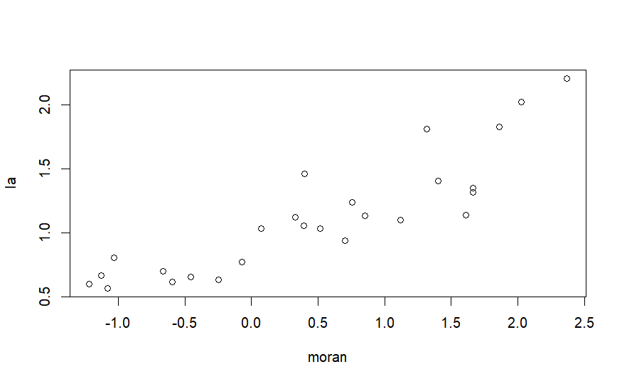

```r
plot(Ia ~ moran, data = beetle_summary)
```

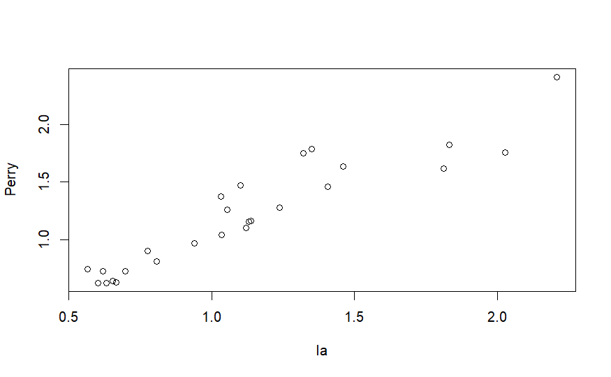

```r
plot(Perry ~ Ia, data = beetle_summary)
```

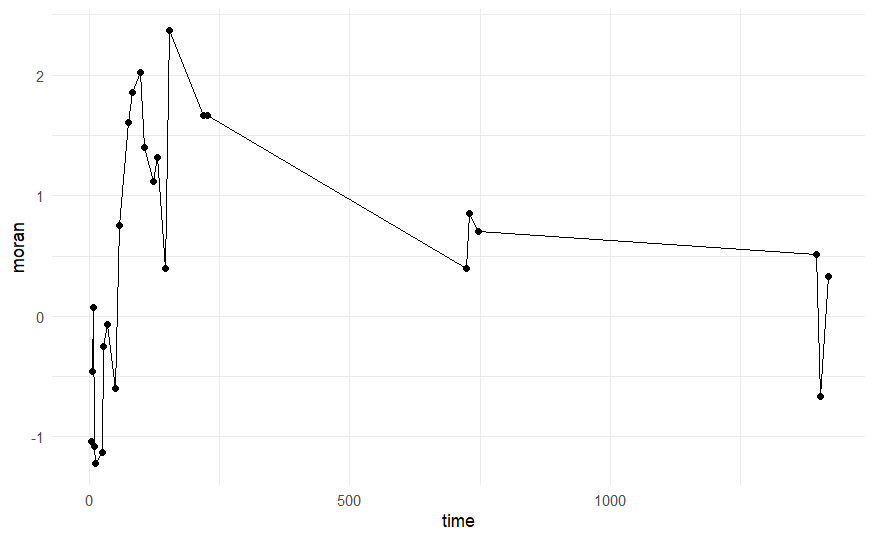

```r
ggplot(beetle_summary, aes(x = time, y = moran)) +
  geom_line() +
  geom_point() +
  #scale_y_log10() +
  theme_minimal()
```

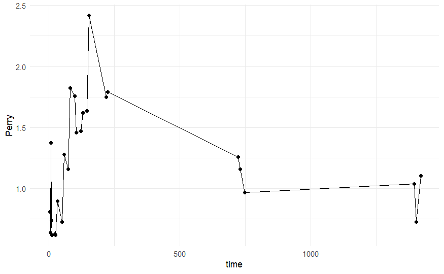

```r
ggplot(beetle_summary, aes(x = time, y = Perry)) +
  geom_line() +
  geom_point() +
  #scale_y_log10() +
  theme_minimal()
```

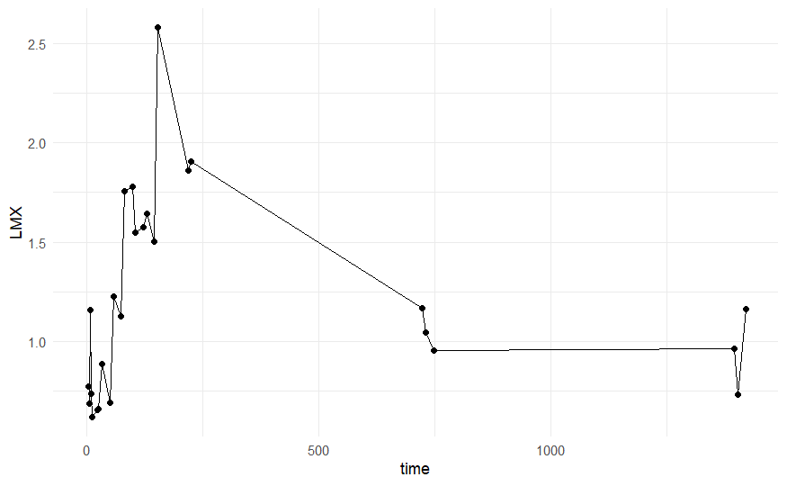

```r
ggplot(beetle_summary, aes(x = time, y = LMX)) +
  geom_line() +
  geom_point() +
  #scale_y_log10() +
  theme_minimal()
```

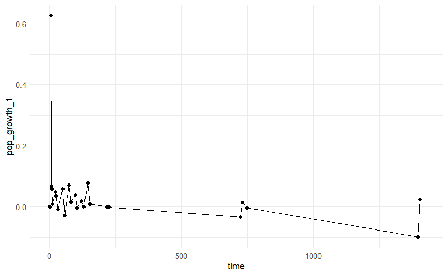

```r
ggplot(beetle_summary, aes(x = time, y = pop_growth_1)) +
  geom_line() +
  geom_point() +
  #scale_y_log10() +
  theme_minimal()
```

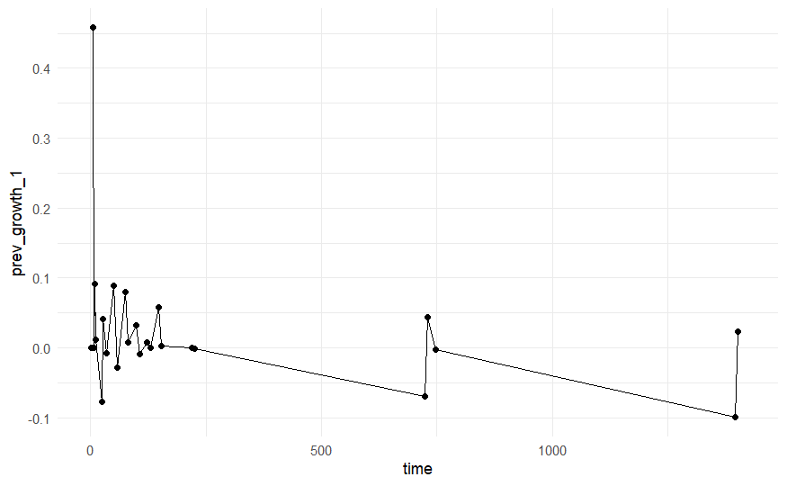

```r
ggplot(beetle_summary, aes(x = time, y = prev_growth_1)) +
  geom_line() +
  geom_point() +
  #scale_y_log10() +
  theme_minimal()
```

#### [5.2] Trial of continuous AR1 model

– NA should be excluded

```r
beetle_summary_temp <- subset(beetle_summary, !is.na(pop_growth_1) & !is.na(smi) & !is.na(LMX))
```

- trial

```r
# exponential growth + unequal time interval (continuous interval)
m_smi <- gls(pop_growth_1 ~ smi,
          data = beetle_summary_temp,
          correlation = corCAR1(form = ~ time),
          method = "REML")
summary(m_smi)
```

```
Generalized least squares fit by REML
  Model: pop_growth_1 ~ smi
  Data: beetle_summary_temp
```

|  | AIC | BIC | logLik |
| --- | --- | --- | --- |
|  | -17.86963 | -13.50546 | 12.93482 |

```
Correlation Structure: Continuous AR(1)
 Formula: ~time
 Parameter estimate(s):
      Phi
0.4287673

Coefficients:
```

|  | Value | Std.Error | t-value | p-value |
| --- | --- | --- | --- | --- |
| (Intercept) | 0.1345215 | 0.06099745 | 2.205362 | 0.0382 |
| smi | -0.2331537 | 0.13107226 | -1.778818 | 0.0891 |

```
 Correlation:
    (Intr)
smi -0.901

Standardized residuals:
        Min          Q1         Med          Q3         Max
-2.01918888 -0.28772490 -0.03375746  0.31954912  3.85475701

Residual standard error: 0.1258238
Degrees of freedom: 24 total; 22 residual
```

```r
summary(m_smi)$tTable
```

```
                 Value  Std.Error   t-value    p-value
(Intercept)  0.1345215 0.06099745  2.205362 0.03817907
smi         -0.2331537 0.13107226 -1.778818 0.08909250
```

```r
m_LMX <- gls(pop_growth_1 ~ LMX,
          data = beetle_summary_temp,
          correlation = corCAR1(form = ~ time),
          method = "REML")
summary(m_LMX)
```

```
Generalized least squares fit by REML
  Model: pop_growth_1 ~ LMX
  Data: beetle_summary_temp
```

|  | AIC | BIC | logLik |
| --- | --- | --- | --- |
|  | -14.61 | -10.24583 | 11.305 |

```
Correlation Structure: Continuous AR(1)
 Formula: ~time
 Parameter estimate(s):
      Phi
0.2741161

Coefficients:
```

|  | Value | Std.Error | t-value | p-value |
| --- | --- | --- | --- | --- |
| (Intercept) | 0.1165392 | 0.07035602 | 1.656422 | 0.1118 |
| LMX | -0.0625721 | 0.05259684 | -1.189655 | 0.2469 |

```
 Correlation:
    (Intr)
LMX -0.925

Standardized residuals:
        Min          Q1         Med          Q3         Max
-1.20068941 -0.38743764 -0.11136382  0.08884556  4.27129815

Residual standard error: 0.1293936
Degrees of freedom: 24 total; 22 residual
```

```r
summary(m_LMX)$tTable
```

```
                 Value  Std.Error   t-value   p-value
(Intercept)  0.1165392 0.07035602  1.656422 0.1118314
LMX         -0.0625721 0.05259684 -1.189655 0.2468631
```

```r
AICc(m_smi, m_LMX)
```

|  | df | AICc |
| --- | --- | --- |
| m_smi | 4 | -15.76437 |
| m_LMX | 4 | -12.50474 |

- visualization

```r
pred_m_cont <- data.frame(
  obs = beetle_summary_temp$pop_growth_1,
  pred_mi = predict(m_smi, newdata = beetle_summary_temp),
  pred_LMX = predict(m_LMX, newdata = beetle_summary_temp)
)

pred_long_m_cont <- rbind(
  data.frame(model = "LMX", pred = pred_m_cont$pred_LMX, obs = pred_m_cont$obs),
  data.frame(model = "std_mi", pred = pred_m_cont$pred_mi, obs = pred_m_cont$obs)
)
```

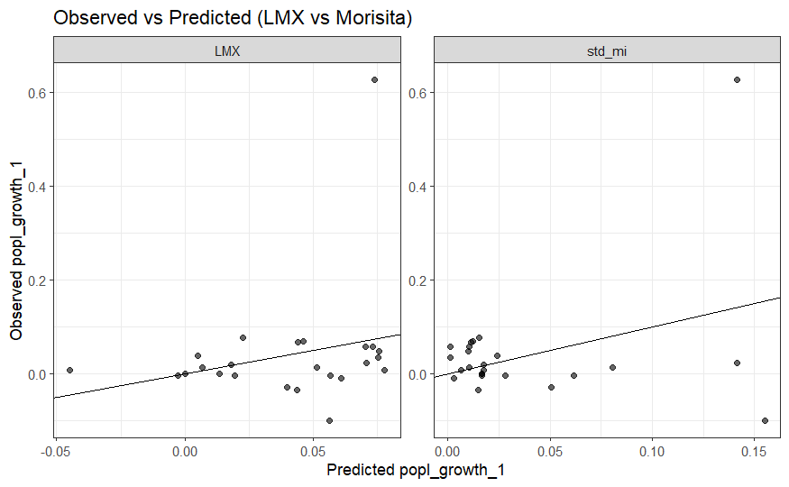

```r
ggplot(pred_long_m_cont, aes(x = pred, y = obs)) +
  geom_point(alpha = 0.6) +
  geom_abline(slope = 1, intercept = 0) +
  facet_wrap(~ model, scales = "free") +
  labs(y = "Observed popl_growth_1",
       x = "Predicted popl_growth_1",
       title = "Observed vs Predicted (LMX vs Morisita)") +
  theme_bw()
```

#### [5.3] Population growth rate 1 by continuous AR1 model

```r
## =========================================================
## 1) Data prearrangement
## =========================================================
## It is better to exclude the final 4 time points because of too long time interval between time 747 (day 32) and time 1395 (day 60)
beetle_summary_CAR1 <- subset(beetle_summary[1:26, ], !is.na(pop_growth_1) & !is.na(smi) & !is.na(LMX))
print(beetle_summary_CAR1)
```

|  | time | infestation_ratio | av_pop | av_impact | smi | pop_growth_1 | prev_growth_1 | Perry | LMX | Ia | moran |
| --- | --- | --- | --- | --- | --- | --- | --- | --- | --- | --- | --- |
| 6 | 6 | 0.04166667 | 0.04166667 | 1.000000 | -0.02933617 | 0.626381484 | 0.458145366 | 0.6382422 | 0.6845912 | 0.6540889 | -0.45667225 |
| 7 | 8 | 0.10416667 | 0.14583333 | 1.400000 | 0.52741834 | 0.066765696 | 0.000000000 | 1.3745602 | 1.1601377 | 1.0325127 | 0.07083704 |
| 8 | 10 | 0.10416667 | 0.16666667 | 1.600000 | 0.57167799 | 0.058891518 | 0.091160778 | 0.7401421 | 0.7352771 | 0.5650081 | -1.07877359 |
| 9 | 12 | 0.12500000 | 0.18750000 | 1.500000 | 0.54952336 | 0.008104655 | 0.011857745 | 0.6186818 | 0.6187522 | 0.6020230 | -1.22025837 |
| 10 | 25 | 0.14583333 | 0.20833333 | 1.428571 | 0.53453603 | 0.047655090 | -0.077075340 | 0.6267382 | 0.6556228 | 0.6657090 | -1.12889208 |
| 11 | 27 | 0.12500000 | 0.22916667 | 1.833333 | 0.57255382 | 0.034451722 | 0.041097439 | 0.6190802 | 0.6604334 | 0.6312965 | -0.24631067 |
| 12 | 34 | 0.16666667 | 0.29166667 | 1.750000 | 0.56429710 | -0.009067687 | -0.007854788 | 0.8989277 | 0.8872188 | 0.7746176 | -0.07148274 |
| 13 | 51 | 0.14583333 | 0.25000000 | 1.714286 | 0.53242714 | 0.057923587 | 0.088434173 | 0.7255507 | 0.6931772 | 0.6193427 | -0.59616735 |
| 14 | 58 | 0.27083333 | 0.37500000 | 1.384615 | 0.36021935 | -0.028969205 | -0.028559283 | 1.2783038 | 1.2258168 | 1.2370960 | 0.75495644 |
| 15 | 75 | 0.16666667 | 0.22916667 | 1.375000 | 0.52398039 | 0.070353784 | 0.079945113 | 1.1606407 | 1.1248911 | 1.1384018 | 1.60854222 |

[output cut: 11 more lines]

##### Visualization for the manuscript (Fig.1, 2)

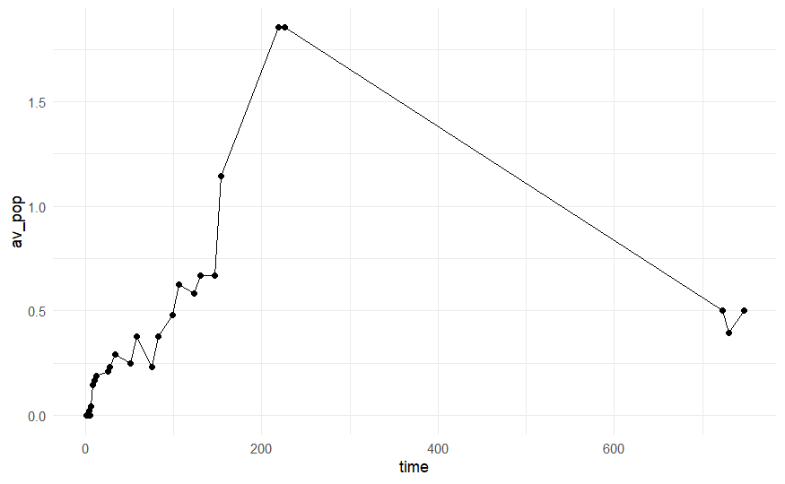

```r
ggplot(beetle_summary[1:27, ], aes(x = time, y = av_pop)) +
  geom_line() +
  geom_point() +
  #scale_y_log10() +
  theme_minimal()
```

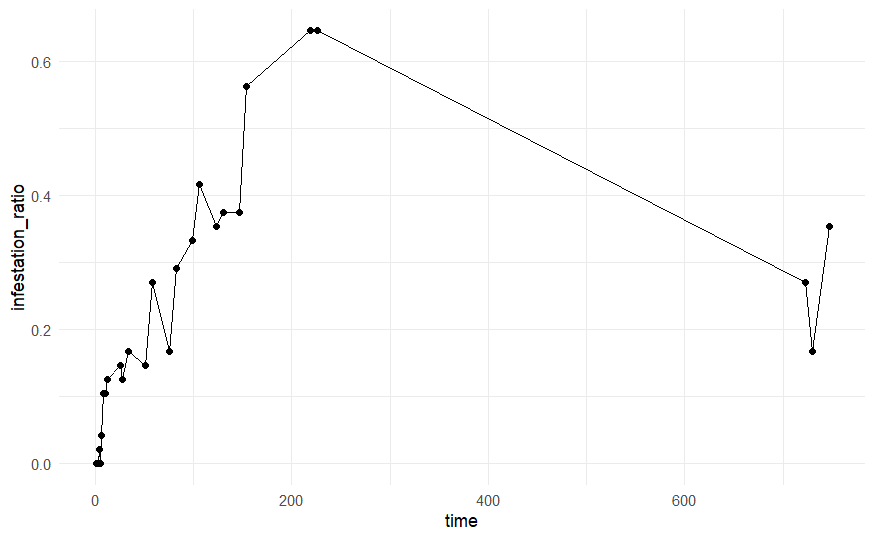

```r
ggplot(beetle_summary[1:27, ], aes(x = time, y = infestation_ratio)) +
  geom_line() +
  geom_point() +
  #scale_y_log10() +
  theme_minimal()
```

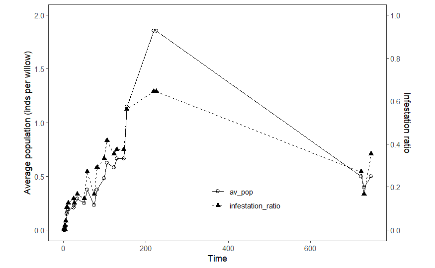

```r
ggplot(beetle_summary[1:27, ], aes(x = time)) +

  # av_pop: solid line + filled circle
  geom_line(aes(y = av_pop, linetype = "av_pop")) +
  geom_point(aes(y = av_pop, shape = "av_pop"),
             size = 2) +

  # infestation_ratio: dashed line + triangle
  geom_line(aes(y = infestation_ratio * 2.0,
                linetype = "infestation_ratio")) +
  geom_point(aes(y = infestation_ratio * 2.0,
                 shape = "infestation_ratio"),
             size = 2) +

  scale_linetype_manual(
    values = c(
      "av_pop" = "solid",
      "infestation_ratio" = "dashed"
    )
  ) +

  scale_shape_manual(
    values = c(
      "av_pop" = 1,               # open circle
      "infestation_ratio" = 17     # filled triangle
    )
  ) +

  scale_y_continuous(
    name = "Average population (inds per willow)",
    limits = c(0, 2),

    sec.axis = sec_axis(
      ~ . / 2,
      name = "Infestation ratio",
      breaks = seq(0, 1, 0.2)
    )
  ) +

  theme_bw() +
  labs(
    x = "Time",
    linetype = NULL,
    shape = NULL
  ) +
  theme(
    aspect.ratio = 0.7,
    panel.grid = element_blank(),
    legend.position = c(0.7, 0.1),
    legend.justification = c(1, 0)
  )
```

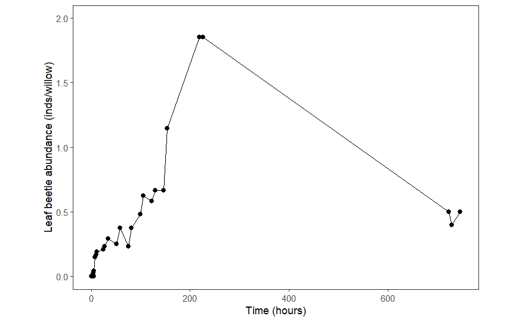

```r
ggplot(beetle_summary[1:27, ], aes(x = time)) +

  # av_pop: solid line + filled circle
  geom_line(aes(y = av_pop)) +
  geom_point(aes(y = av_pop),
             size = 2) +

  scale_y_continuous(
    name = "Leaf beetle abundance (inds/willow)",
    limits = c(0, 2),
  ) +

  theme_bw() +
  labs(
    x = "Time (hours)",
    linetype = NULL,
    shape = NULL
  ) +
  theme(
    aspect.ratio = 0.7,
    panel.grid = element_blank(),
    legend.position = c(0.7, 0.1),
    legend.justification = c(1, 0)
  )
```

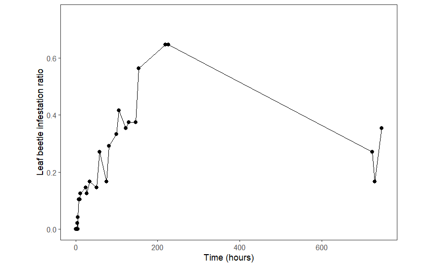

```r
ggplot(beetle_summary[1:27, ], aes(x = time)) +

  # av_pop: solid line + filled circle
  geom_line(aes(y = infestation_ratio)) +
  geom_point(aes(y = infestation_ratio),
             size = 2) +

  scale_y_continuous(
    name = "Leaf beetle infestation ratio",
    limits = c(0, 0.75),
  ) +

  theme_bw() +
  labs(
    x = "Time (hours)",
    linetype = NULL,
    shape = NULL
  ) +
  theme(
    aspect.ratio = 0.7,
    panel.grid = element_blank(),
    legend.position = c(0.7, 0.1),
    legend.justification = c(1, 0)
  )
```

– Visualization for SI

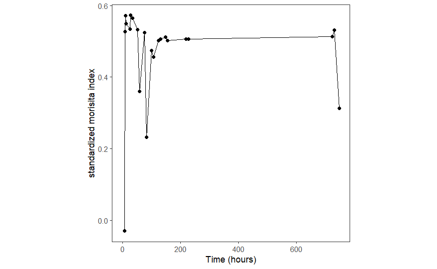

```r
ggplot(beetle_summary[1:27, ], aes(x = time, y = smi)) +
  geom_line() +
  geom_point() +
  #scale_y_log10() +
  theme_bw() +
  labs(
    x = "Time (hours)",
    y = "standardized morisita index",
    linetype = NULL,
    shape = NULL
  ) +
  theme(
    aspect.ratio = 1.0,
    panel.grid = element_blank(),
    #legend.position = c(0.7, 0.1),
    #legend.justification = c(1, 0)
  )
```

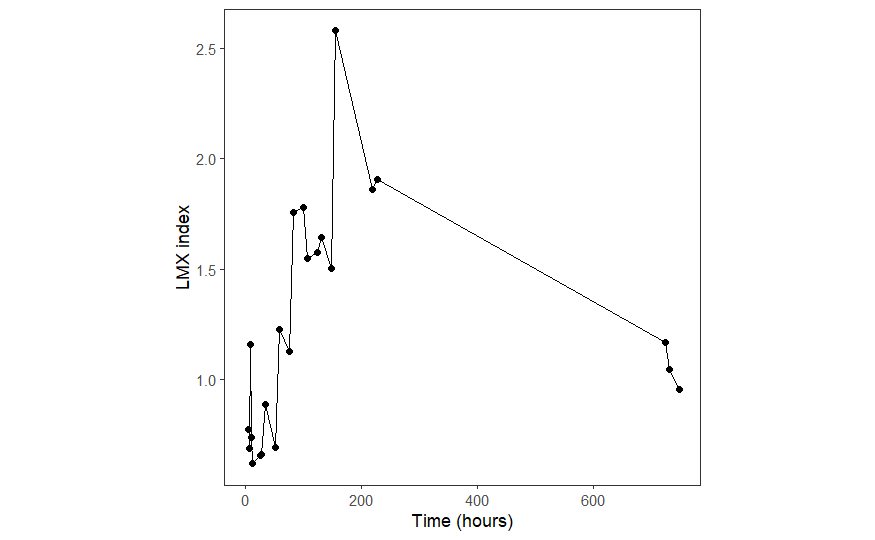

```r
ggplot(beetle_summary[1:27, ], aes(x = time, y = LMX)) +
  geom_line() +
  geom_point() +
  #scale_y_log10() +
  theme_bw() +
  labs(
    x = "Time (hours)",
    y = "LMX index",
    linetype = NULL,
    shape = NULL
  ) +
  theme(
    aspect.ratio = 1.0,
    panel.grid = element_blank(),
    #legend.position = c(0.7, 0.1),
    #legend.justification = c(1, 0)
  )
```

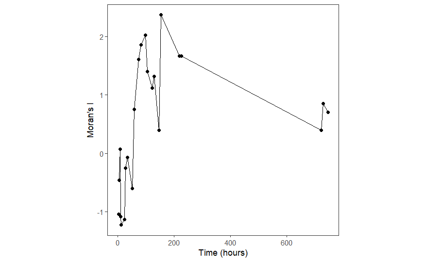

```r
ggplot(beetle_summary[1:27, ], aes(x = time, y = moran)) +
  geom_line() +
  geom_point() +
  #scale_y_log10() +
  theme_bw() +
  labs(
    x = "Time (hours)",
    y = "Moran's I",
    linetype = NULL,
    shape = NULL
  ) +
  theme(
    aspect.ratio = 1.0,
    panel.grid = element_blank(),
    #legend.position = c(0.7, 0.1),
    #legend.justification = c(1, 0)
  )
```

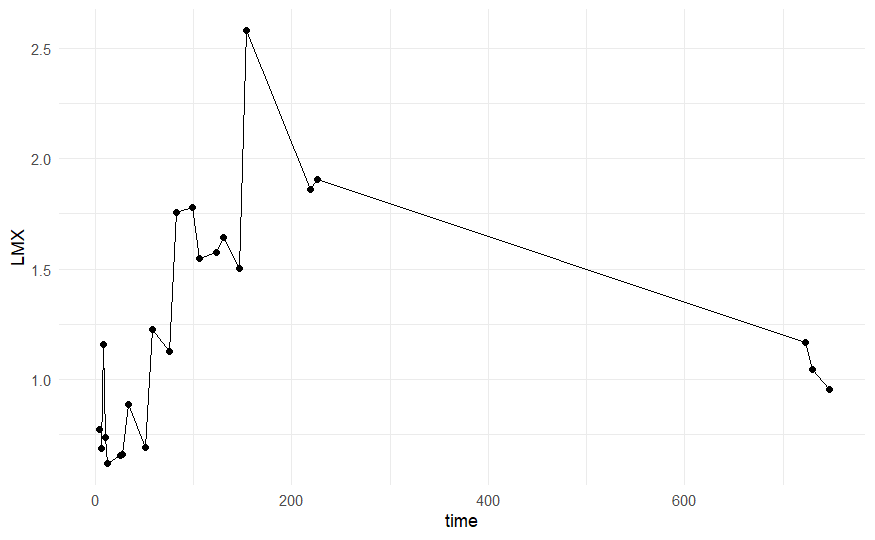

```r
ggplot(beetle_summary[1:27, ], aes(x = time, y = LMX)) +
  geom_line() +
  geom_point() +
  #scale_y_log10() +
  theme_minimal()
```

- Codes for snapshot (for Fig.2)

```r
# setting the max and min for color gradient
adult_min <- 0
adult_max <- 10
beetle_summary$time[22]
```

```
[1] 154
```

```r
unique(adult_time_space$X)
```

```
[1] 0 2
```

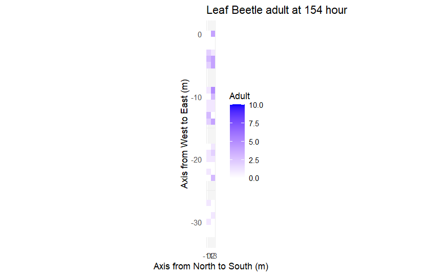

```r
sub_adult_time_space <- subset(adult_time_space, time == 22)

ggplot(sub_adult_time_space, aes(x = X, y = Y, fill = adult)) +
  geom_tile() +
  scale_fill_gradient(low = "white", high = "blue", limits = c(adult_min, adult_max)) +
  labs(title = "Leaf Beetle adult at 154 hour",
       x = "Axis from North to South (m)",
       y = "Axis from West to East (m)",
       fill = "Adult") + coord_fixed(ratio = 3.0) +
  theme_minimal()
```

##### Analysis

– Check colinearity before preparing the candidate models - Noting that Perry, LMX, and Ia are part of SADIE and include almost the same information. Choose LMX only because this is the updated version of Ia and Perry.

```r
cor(beetle_summary_CAR1[, c("infestation_ratio", "av_pop", "smi", "Perry", "LMX", "Ia", "moran")])
```

```
                  infestation_ratio    av_pop          smi        Perry
infestation_ratio         1.0000000 0.9424405  0.128444651  0.825602992
av_pop                    0.9424405 1.0000000  0.157210604  0.673030775
smi                       0.1284447 0.1572106  1.000000000 -0.001142684
Perry                     0.8256030 0.6730308 -0.001142684  1.000000000
LMX                       0.8752098 0.7286071 -0.010191164  0.985516550
Ia                        0.6854006 0.4790617 -0.082058296  0.930604418
moran                     0.7438537 0.6004444 -0.081089016  0.892793523
                          LMX         Ia       moran
infestation_ratio  0.87520982  0.6854006  0.74385372
av_pop             0.72860710  0.4790617  0.60044441
smi               -0.01019116 -0.0820583 -0.08108902
Perry              0.98551655  0.9306044  0.89279352
LMX                1.00000000  0.9144056  0.89719604
Ia                 0.91440564  1.0000000  0.88543097
moran              0.89719604  0.8854310  1.00000000
```

```r
## =========================================================
## 2) DEFINE CANDIDATE MODELS (all subsets)
## =========================================================
# Model list as formulas; includes intercept-only baseline
candidate_formulas$pop_growth_1 <- list(
  m0 = as.formula("pop_growth_1 ~ 1"),
  m_pop = as.formula("pop_growth_1 ~ av_pop"),
  m_prev = as.formula("pop_growth_1 ~ infestation_ratio"),
  m_mi = as.formula("pop_growth_1 ~ smi"),
  m_LMX = as.formula("pop_growth_1 ~ LMX"),
  m_moran = as.formula("pop_growth_1 ~ moran"),
  m_pop_prev = as.formula("pop_growth_1 ~ av_pop + infestation_ratio"),
  m_pop_mi = as.formula("pop_growth_1 ~ av_pop + smi"),
  m_pop_LMX = as.formula("pop_growth_1 ~ av_pop + LMX"),
  m_pop_moran = as.formula("pop_growth_1 ~ av_pop + moran"),
  m_prev_mi = as.formula("pop_growth_1 ~ infestation_ratio + smi"),
  m_prev_LMX = as.formula("pop_growth_1 ~ infestation_ratio + LMX"),
  m_prev_LMX = as.formula("pop_growth_1 ~ infestation_ratio + moran"),
  m_mi_LMX = as.formula("pop_growth_1 ~ smi + LMX"),
  m_mi_moran = as.formula("pop_growth_1 ~ smi + moran"),
  m_moran_LMX = as.formula("pop_growth_1 ~ moran + LMX"),
  m_pop_prev_mi = as.formula("pop_growth_1 ~ av_pop + infestation_ratio + smi"),
  m_pop_prev_LMX = as.formula("pop_growth_1 ~ av_pop + infestation_ratio + LMX"),
  m_pop_prev_moran = as.formula("pop_growth_1 ~ av_pop + infestation_ratio + moran"),
  m_pop_mi_LMX = as.formula("pop_growth_1 ~ av_pop + smi + LMX"),
  m_prev_mi_LMX = as.formula("pop_growth_1 ~ infestation_ratio + smi + LMX"),
  m_pop_mi_moran = as.formula("pop_growth_1 ~ av_pop + smi + moran"),
  m_prev_mi_moran = as.formula("pop_growth_1 ~ infestation_ratio + smi + moran"),
  m_pop_moran_LMX = as.formula("pop_growth_1 ~ av_pop + moran + LMX"),
  m_prev_moran_LMX = as.formula("pop_growth_1 ~ infestation_ratio + moran + LMX"),
  m_mi_moran_LMX = as.formula("pop_growth_1 ~ smi + moran + LMX"),
  m_pop_prev_mi_LMX = as.formula("pop_growth_1 ~ av_pop + infestation_ratio + smi + LMX"),
  m_pop_prev_mi_moran = as.formula("pop_growth_1 ~ av_pop + infestation_ratio + smi + moran"),
  m_pop_prev_LMX_moran = as.formula("pop_growth_1 ~ av_pop + infestation_ratio + LMX + moran"),
  m_pop_mi_LMX_moran = as.formula("pop_growth_1 ~ av_pop + smi + LMX + moran"),
  m_prev_mi_LMX_moran = as.formula("pop_growth_1 ~ infestation_ratio + smi + LMX + moran"),
  m_all = as.formula("pop_growth_1 ~ av_pop + infestation_ratio + smi + LMX + moran")
)
```

– Candidate models were primarily evaluated based on predictive performance using rolling one-step-ahead forecasts over the final K time points. To account for small sample size and facilitate comparison from an information-theoretic perspective, AICc values were additionally computed and reported as a complementary criterion.

```r
## =========================================================
## 3) Fit all models by ML for calculating AICc using all time points
## =========================================================
fits_gls$pop_growth_1 <- lapply(candidate_formulas$pop_growth_1, function(fm) {
  try(
    gls(fm,
        data = beetle_summary_CAR1,
        correlation = corCAR1(form = ~ time),
        method = "ML",
        na.action = na.omit),
    silent = TRUE
  )
})
#fits_gls$pop_growth_1

aicc <- sapply(fits_gls$pop_growth_1, AICc)
```

```r
## =========================================================
## 4) Calculating RMSE by rolling 1-step ahead by the last K time points
## =========================================================
rolling_lastK_metrics <- function(df, forms, K,
                                  time_col = "time",
                                  y_col = "y",
                                  min_train = 10) {

  #cor_struct <- corCAR1(form = as.formula(paste0("~", time_col)))
  df <- df[order(df[[time_col]]), ]
  n <- nrow(df)
  stopifnot(n >= (min_train + K))

  start <- n - K

  eval_one <- function(form) {
    preds <- rep(NA_real_, n)

    for (t0 in start:(n - 1)) {
      train <- df[1:t0, , drop = FALSE]
      test  <- df[t0 + 1, , drop = FALSE]

      fit <- try(gls(form, data = train,
                     correlation = corCAR1(form = ~ time),
                     method = "ML",
                     na.action = na.omit),
                 silent = TRUE)
      if (inherits(fit, "try-error")) next

      pr <- try(as.numeric(predict(fit, newdata = test)), silent = TRUE)
      if (inherits(pr, "try-error")) next

      preds[t0 + 1] <- pr
    }

    ok <- !is.na(preds) & !is.na(df[[y_col]])
    e <- df[[y_col]][ok] - preds[ok]
    data.frame(
      RMSE = sqrt(mean(e^2, na.rm = TRUE)),
      MAE  = mean(abs(e), na.rm = TRUE),
      n_test = sum(ok),
      pred1 = preds[start + 1], # specific for K = 6
      pred2 = preds[start + 2],
      pred3 = preds[start + 3],
      pred4 = preds[start + 4],
      pred5 = preds[start + 5],
      pred6 = preds[start + 6],
      e1 = abs(e[1]), # specific for K = 6
      e2 = abs(e[2]),
      e3 = abs(e[3]),
      e4 = abs(e[4]),
      e5 = abs(e[5]),
      e6 = abs(e[6]),
      stringsAsFactors = FALSE
    )

  }

  res_list <- lapply(forms, eval_one)
  # summarizing into dataframe
  out <- do.call(rbind, res_list)
  out$model <- names(forms)
  out <- out[, c("model", "n_test", "RMSE", "MAE", "pred1", "pred2", "pred3", "pred4", "pred5", "pred6", "e1", "e2", "e3", "e4", "e5", "e6")]
  #out
}
```

```r
results_temp <- rolling_lastK_metrics(
  df = beetle_summary_CAR1,
  forms = candidate_formulas$pop_growth_1,
  K = 6,
  time_col = "time",
  y_col = "pop_growth_1"
  )
print(results_temp)
```

|  | model | n_test | RMSE | MAE | pred1 | pred2 | pred3 | pred4 | pred5 | pred6 | e1 | e2 | e3 | e4 | e5 | e6 |
| --- | --- | --- | --- | --- | --- | --- | --- | --- | --- | --- | --- | --- | --- | --- | --- | --- |
| m0 | m0 | 6 | 0.05930227 | 0.05401935 | 0.066506115 | 0.0672262370 | 0.063519364 | 0.0597906802 | 0.05631059 | 0.051540476 | 0.01086492 | 0.059821573 | 0.063519364 | 0.062427667 | 0.08968414 | 0.037798426 |
| m_pop | m_pop | 6 | 0.15500284 | 0.13881303 | -0.077728155 | -0.2039682958 | -0.239206321 | -0.0847148500 | 0.06080201 | 0.064688311 | 0.15509920 | 0.211372960 | 0.239206321 | 0.082077863 | 0.09417556 | 0.050946261 |
| m_prev | m_prev | 6 | 0.10395585 | 0.10125573 | -0.040835180 | -0.1280899371 | -0.114244946 | -0.0733665334 | 0.06100956 | 0.088218012 | 0.11820622 | 0.135494601 | 0.114244946 | 0.070729546 | 0.09438311 | 0.074475962 |
| m_mi | m_mi | 6 | 0.03649788 | 0.03138909 | 0.009891005 | 0.0231652727 | 0.019488696 | 0.0182387141 | 0.01082470 | -0.006789202 | 0.06748004 | 0.015760608 | 0.019488696 | 0.020875701 | 0.04419825 | 0.020531252 |
| m_LMX | m_LMX | 6 | 0.06706210 | 0.05604435 | 0.020528138 | -0.0924776024 | 0.011462207 | 0.0063170428 | 0.06745470 | 0.072038476 | 0.05684290 | 0.099882267 | 0.011462207 | 0.008954030 | 0.10082825 | 0.058296426 |
| m_moran | m_moran | 6 | 0.04438826 | 0.03269765 | 0.065002313 | 0.0009734628 | 0.025243821 | 0.0224560444 | 0.06398819 | 0.043429417 | 0.01236873 | 0.006431202 | 0.025243821 | 0.025093031 | 0.09736174 | 0.029687367 |
| m_pop_prev | m_pop_prev | 6 | 0.11180985 | 0.10054691 | -0.080784357 | -0.1461074754 | 0.083424477 | 0.0092610801 | 0.05915091 | 0.117508941 | 0.15815540 | 0.153512140 | 0.083424477 | 0.011898067 | 0.09252446 | 0.103766891 |
| m_pop_mi | m_pop_mi | 6 | 0.11235243 | 0.09459215 | -0.079306963 | -0.1503828710 | -0.147092034 | -0.0477563606 | 0.01666978 | 0.002909433 | 0.15667800 | 0.157787535 | 0.147092034 | 0.045119374 | 0.05004333 | 0.010832617 |
| m_pop_LMX | m_pop_LMX | 6 | 0.18698632 | 0.15670064 | -0.100988989 | -0.2026001204 | -0.343591710 | -0.0539518402 | 0.06590870 | 0.071392246 | 0.17836003 | 0.210004785 | 0.343591710 | 0.051314853 | 0.09928225 | 0.057650195 |
| m_pop_moran | m_pop_moran | 6 | 0.16692174 | 0.14602803 | -0.121935151 | -0.2129473086 | -0.251963527 | -0.0672762737 | 0.06349096 | 0.056784719 | 0.19930619 | 0.220351973 | 0.251963527 | 0.064639287 | 0.09686451 | 0.043042669 |

[output cut: 22 more lines]

```r
## =========================================================
## 5) Summarize the results into the dataframe, ordering by RMSE
## =========================================================

results_table$pop_growth_1 <- data.frame(
  model = results_temp$model,
  n_test = results_temp$n_test,
  RMSE = results_temp$RMSE,
  MAE = results_temp$MAE,
  AICc = aicc,
  delta = aicc - min(aicc),
  results_temp[, -c(1:4)]   #for predicted rate & errors
)

results_table$pop_growth_1 <- results_table$pop_growth_1[order(results_table$pop_growth_1$RMSE), ]
print(results_table$pop_growth_1)
```

|  | model | n_test | RMSE | MAE | AICc | delta | pred1 | pred2 | pred3 | pred4 | pred5 | pred6 | e1 | e2 | e3 | e4 | e5 | e6 |
| --- | --- | --- | --- | --- | --- | --- | --- | --- | --- | --- | --- | --- | --- | --- | --- | --- | --- | --- |
| m_mi | m_mi | 6 | 0.03649788 | 0.03138909 | -35.574413 | 2.2747110 | 0.009891005 | 0.0231652727 | 0.019488696 | 0.0182387141 | 0.01082470 | -0.006789202 | 0.06748004 | 0.015760608 | 0.019488696 | 0.020875701 | 0.04419825 | 0.020531252 |
| m_moran | m_moran | 6 | 0.04438826 | 0.03269765 | -16.497663 | 21.3514615 | 0.065002313 | 0.0009734628 | 0.025243821 | 0.0224560444 | 0.06398819 | 0.043429417 | 0.01236873 | 0.006431202 | 0.025243821 | 0.025093031 | 0.09736174 | 0.029687367 |
| m_mi_moran | m_mi_moran | 6 | 0.04872619 | 0.04304682 | -37.849124 | 0.0000000 | 0.018703310 | -0.0678878006 | -0.022701161 | -0.0199937871 | 0.02835226 | -0.008794921 | 0.05866773 | 0.075292465 | 0.022701161 | 0.017356800 | 0.06172581 | 0.022536971 |
| m0 | m0 | 6 | 0.05930227 | 0.05401935 | -17.902215 | 19.9469089 | 0.066506115 | 0.0672262370 | 0.063519364 | 0.0597906802 | 0.05631059 | 0.051540476 | 0.01086492 | 0.059821573 | 0.063519364 | 0.062427667 | 0.08968414 | 0.037798426 |
| m_LMX | m_LMX | 6 | 0.06706210 | 0.05604435 | -16.942289 | 20.9068357 | 0.020528138 | -0.0924776024 | 0.011462207 | 0.0063170428 | 0.06745470 | 0.072038476 | 0.05684290 | 0.099882267 | 0.011462207 | 0.008954030 | 0.10082825 | 0.058296426 |
| m_pop_mi_moran | m_pop_mi_moran | 6 | 0.07142677 | 0.05361444 | -33.997647 | 3.8514768 | -0.037699694 | -0.1060080112 | 0.001620313 | 0.0004129357 | 0.02786385 | -0.013553556 | 0.11507073 | 0.113412676 | 0.001620313 | 0.003049923 | 0.06123740 | 0.027295606 |
| m_moran_LMX | m_moran_LMX | 6 | 0.08858320 | 0.07297426 | -13.442361 | 24.4067631 | -0.032806546 | -0.1350099957 | 0.011130721 | 0.0051674160 | 0.06774657 | 0.078940103 | 0.11017759 | 0.142414660 | 0.011130721 | 0.007804403 | 0.10112012 | 0.065198053 |
| m_pop_prev_LMX | m_pop_prev_LMX | 6 | 0.09107826 | 0.06962280 | -12.625146 | 25.2239783 | -0.074458698 | -0.0075352599 | -0.026846075 | 0.0042478320 | 0.04259402 | 0.155010728 | 0.15182974 | 0.014939924 | 0.026846075 | 0.006884819 | 0.07596757 | 0.141268678 |
| m_mi_LMX | m_mi_LMX | 6 | 0.09215241 | 0.07051075 | -37.434840 | 0.4142841 | -0.038765484 | -0.1707009939 | -0.032534724 | -0.0311448192 | 0.02857725 | 0.019570992 | 0.11613652 | 0.178105658 | 0.032534724 | 0.028507832 | 0.06195080 | 0.005828942 |
| m_pop_prev_LMX_moran | m_pop_prev_LMX_moran | 6 | 0.09757689 | 0.07047712 | -8.072872 | 29.7762519 | -0.094834577 | -0.0093102418 | -0.002970474 | 0.0061596806 | 0.04288406 | 0.159659513 | 0.17220562 | 0.016714906 | 0.002970474 | 0.008796668 | 0.07625762 | 0.145917463 |

[output cut: 22 more lines]

```r
## =========================================================
## 6) FINAL REFIT: refit the selected structure on ALL data by REML
##    and report coefficients + CI
## =========================================================
best_model_name$pop_growth_1 <- results_table$pop_growth_1$model[1]
best_formula$pop_growth_1 <- candidate_formulas$pop_growth_1[[best_model_name$pop_growth_1]]
final_fit$pop_growth_1 <- gls(best_formula$pop_growth_1,
                 data = beetle_summary_CAR1,
                 correlation = corCAR1(form = ~ time),
                 method = "REML",
                 na.action = na.omit)

cat("\nFinal model (REML) summary:\n")
```

```
Final model (REML) summary:
```

```r
print(summary(final_fit$pop_growth_1))
```

```
Generalized least squares fit by REML
  Model: best_formula$pop_growth_1
  Data: beetle_summary_CAR1
```

|  | AIC | BIC | logLik |
| --- | --- | --- | --- |
|  | -29.76963 | -25.99188 | 18.88482 |

```
Correlation Structure: Continuous AR(1)
 Formula: ~time
 Parameter estimate(s):
      Phi
0.6799843

Coefficients:
```

|  | Value | Std.Error | t-value | p-value |
| --- | --- | --- | --- | --- |
| (Intercept) | 0.4204256 | 0.06323805 | 6.648301 | 0 |
| smi | -0.8005564 | 0.12645469 | -6.330776 | 0 |

```
 Correlation:
    (Intr)
smi -0.944

Standardized residuals:
       Min         Q1        Med         Q3        Max
-2.5313352 -0.1808419  0.2170756  0.7610451  2.0979522

Residual standard error: 0.08697559
Degrees of freedom: 21 total; 19 residual
```

```r
cat("\nFixed effects (tTable):\n")
```

```
Fixed effects (tTable):
```

```r
print(summary(final_fit$pop_growth_1)$tTable)
```

```
                 Value  Std.Error   t-value      p-value
(Intercept)  0.4204256 0.06323805  6.648301 2.329912e-06
smi         -0.8005564 0.12645469 -6.330776 4.480481e-06
```

– Alternative model

```r
alternative_model <- gls(candidate_formulas$pop_growth_1$m_prev,
                 data = beetle_summary_CAR1,
                 correlation = corCAR1(form = ~ time),
                 method = "REML",
                 na.action = na.omit)

cat("\nFinal model (REML) summary:\n")
```

```
Final model (REML) summary:
```

```r
print(summary(alternative_model))
```

```
Generalized least squares fit by REML
  Model: candidate_formulas$pop_growth_1$m_prev
  Data: beetle_summary_CAR1
```

|  | AIC | BIC | logLik |
| --- | --- | --- | --- |
|  | -13.44576 | -9.668 | 10.72288 |

```
Correlation Structure: Continuous AR(1)
 Formula: ~time
 Parameter estimate(s):
         Phi
6.806327e-05

Coefficients:
```

|  | Value | Std.Error | t-value | p-value |
| --- | --- | --- | --- | --- |
| (Intercept) | 0.1321679 | 0.05289843 | 2.498523 | 0.0218 |
| infestation_ratio | -0.2936802 | 0.16145172 | -1.818997 | 0.0847 |

```
 Correlation:
                  (Intr)
infestation_ratio -0.848

Standardized residuals:
        Min          Q1         Med          Q3         Max
-0.71791415 -0.47456619 -0.24438442  0.02865054  3.93966944

Residual standard error: 0.1285515
Degrees of freedom: 21 total; 19 residual
```

```r
cat("\nFixed effects (tTable):\n")
```

```
Fixed effects (tTable):
```

```r
print(summary(alternative_model)$tTable)
```

```
                       Value  Std.Error   t-value    p-value
(Intercept)        0.1321679 0.05289843  2.498523 0.02180822
infestation_ratio -0.2936802 0.16145172 -1.818997 0.08470950
```

##### Visualization 00

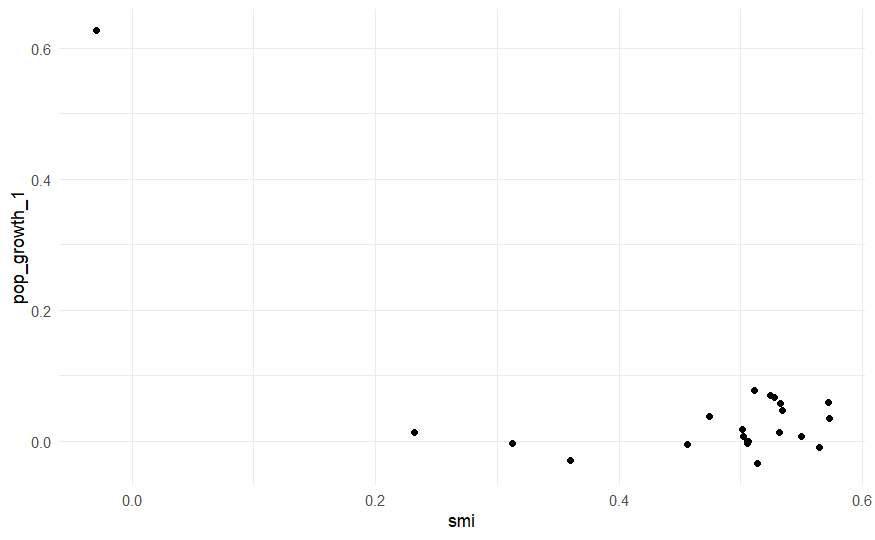

```r
ggplot(beetle_summary[1:27, ], aes(x = smi, y = pop_growth_1)) +
  geom_point() +
  #scale_y_log10() +
  theme_minimal()
```

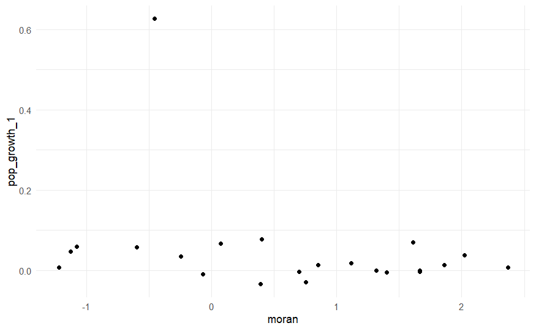

```r
ggplot(beetle_summary[1:27, ], aes(x = moran, y = pop_growth_1)) +
  geom_point() +
  #scale_y_log10() +
  theme_minimal()
```

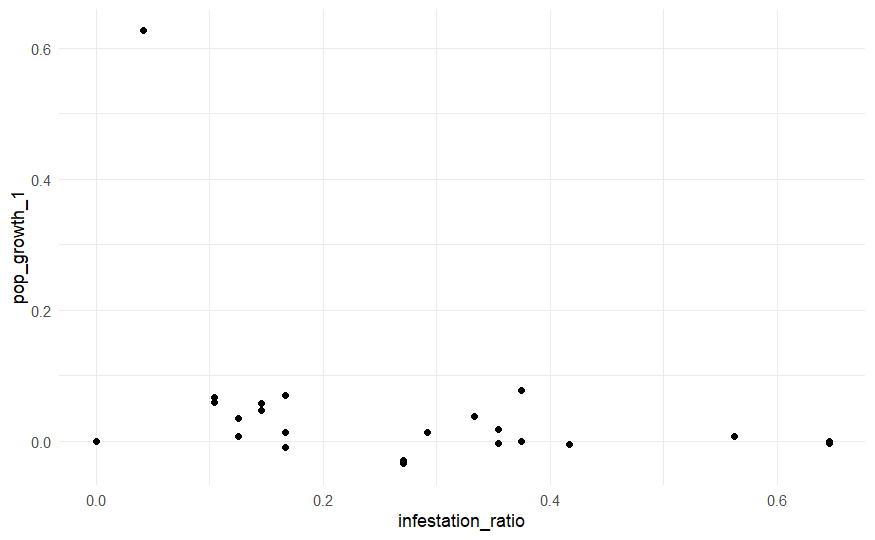

```r
ggplot(beetle_summary[1:27, ], aes(x = infestation_ratio, y = pop_growth_1)) +
  geom_point() +
  #scale_y_log10() +
  theme_minimal()
```

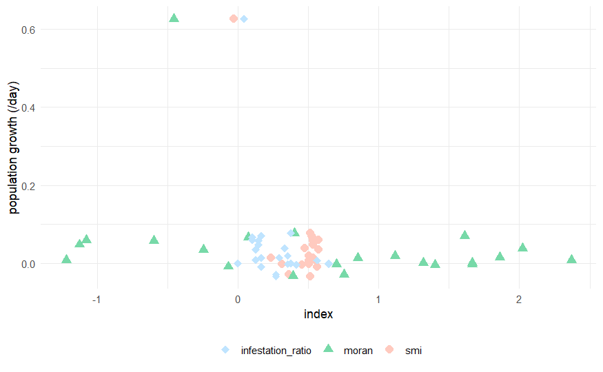

```r
ggplot(beetle_summary[1:27, ], aes(y = pop_growth_1)) +

  # smi: filled circle
  geom_point(aes(x = smi, shape = "smi"),
             size = 3, color = "#ffcabf") +

  # moran: triangle
  geom_point(aes(x = moran, shape = "moran"),
             size = 3, color = "#77d9a8") +

  # infestation ratio: diamon
  geom_point(aes(x = infestation_ratio, shape = "infestation_ratio"),
             size = 3, color = "#bfe4ff") +

  scale_shape_manual(
    values = c(
      "smi" = 16,               # filled circle
      "moran" = 17,     # filled triangle
      "infestation_ratio" = 18  # filled diamond
    )
  ) +

  theme_minimal() +
  labs(
    x = "index",
    y = "population growth (/day)",
    linetype = NULL,
    shape = NULL
  ) +
  theme(
    legend.position = "bottom"
  )
```